# Offline Multi-Armed Bandit (MAB)

## Introduction

MAB can be seen as a single state Reinforcement learning (RL) formulation. Mathematically we can define MAB as follows:

Let,

1. $S=\{s_0, s_1, ...\}$ is the state set. It is also referred to as context in MAB. $|S|=n$
2. $A=\{a_0, a_1, ...\}$ is action set and $|A|=K$.
3. $R=\{r_1, r_2, ...\}$ is reward set, associated with each action and $r_k \in R$ is representing reward distribution of $a_k \in A$ action. For example, $r_k = \mathcal{N}(\mu_k,\,\sigma^{2})$.
4. Policy $\pi = p(a_i|s_i)$ represents a distribution over action space conditioned on input state.

A policy can be evaluated as follows,

1. Dataset $D_{\pi}=\{(s_i, a_i, r_i)\}_{i=1}^{n}$ is generated by $n$ interactions of MAB using policy $\pi$. Expected reward is defined as $\mathbb{E}[r] = \sum_{i=1}^{n}r_i$ = $\hat{V}(\pi; D_{\pi}) \sim V(\pi)$.
2. Our goal is to evaluate the policy $\pi_e$ using a dataset $D_{\pi_0}$ generated using behavior policy $\pi_0$. Hypothesis is $\hat{V}(\pi_e; D_{\pi_0}) \sim V(\pi_e)$.

For more details on Offline Policy Evaluation, refer to my previous blog [Offline Reinforcement Learning](https://www.linkedin.com/feed/update/urn:li:activity:7010685638425337856?utm_source=share&utm_medium=member_desktop).

## Policy estimator

Hypothesis is that $\hat{V}(\pi^*; D_{\pi_0})$ is good measure of $V(\pi^*)$ i.e. $V(\pi^*) \sim \hat{V}(\pi^*; D_{\pi_0})$. For evaluating $\hat{V}(\pi^*; D_{\pi_0})$, will use IPS and SNIPS estimator, defined as follows:

### Inverse Propensity Score (IPS)

IPS estimator is defined as $$\hat{V}_{IPS}(\pi_e; D_0) = \frac{1}{n} \sum_{i=1}^{n} \frac{\pi_e(a_i | s_i)}{\pi_0(a_i | s_i)} * r_i$$

### Self-Normalized IPS (SNIPS) Estimator

SNIPS rescales the estimate of the vanilla IPS $$\hat{V}_{SNIPS}(\pi_e; D_0) = \frac{\frac{1}{n} \sum_{i=1}^{n} \frac{\pi_e(a_i | s_i)}{\pi_0(a_i | s_i)} * r_i}{\frac{1}{n} \sum_{i=1}^{n} \frac{\pi_e(a_i | s_i)}{\pi_0(a_i | s_i)}} = \frac{\sum_{i=1}^{n} \frac{\pi_e(a_i | s_i)}{\pi_0(a_i | s_i)} * r_i}{\sum_{i=1}^{n} \frac{\pi_e(a_i | s_i)}{\pi_0(a_i | s_i)}}$$

In the above estimators, $\pi_0$ is used but in practical scenarios, it is not known. So our goal is to test the estimator using $\hat{\pi}_0$. For more experimental details, refer to my [previous blog](https://www.linkedin.com/feed/update/urn:li:activity:7010685638425337856?utm_source=share&utm_medium=member_desktop) or [DM](https://www.linkedin.com/in/amit-singh-8a8868ba/) me.

```python
from IPython.display import display, HTML
display(HTML("<style>.container { width:100% !important; }</style>"))

import numpy as np
import sys
import matplotlib.pyplot as plt
plt.rcParams["figure.figsize"] = (10,6)

import warnings
warnings.filterwarnings("ignore")
```

```python
class MAB():
    def __init__(self, grid_size):
        self.grid_size = grid_size
        self.num_state = grid_size*grid_size
        self.action_space = [-1,1,-grid_size, grid_size]
        self.state_space = [i for i in range(self.num_state)]
        self.end_state = self.num_state
        self.end_reward = 100
        self.discount = 0.9
        self.penalty = -3
        self.discounted_reward_mean = self.discountedRewardMean()
        self.normalizePolicy = lambda policy : (policy+1e-2)/(policy+1e-2).sum(axis=1, keepdims=True)
        self.optimal_policy = self.getOptimalPolicy()

    def rewardGenerator(self,s,a,scale=1.0):
        s_ = s+a
        u = 0
        if s_==self.end_state:
            u = self.end_reward
        elif s_<0 or s_>self.end_state:
            u = self.penalty
        else:
            u = self.discounted_reward_mean[s_]
        return np.random.normal(loc=u, scale=scale, size=None)

    def getTruePolicyValue(self,policy):
        v = 0
        for s in range(self.num_state):
            for a_idx, a in enumerate(self.action_space):
                v += self.rewardGenerator(s,a,0)*policy[s,a_idx]
        v /= self.num_state
        return v

    def discountedRewardMean(self):
        discounted_reward = np.zeros(self.num_state)
        alpha = self.discount
        explored = [self.end_state]
        it = 100
        while explored != []:
            new_explored = []
            for e in explored:
                for a in self.action_space:
                    s = e-a
                    if s>=0 and s<self.num_state and discounted_reward[s]==0:
                        discounted_reward[s] = 100*alpha
                        new_explored.append(s)
            alpha*=self.discount
            explored = new_explored
        return discounted_reward

    def getOptimalPolicy(self):
        optimal_policy = np.zeros((self.num_state, len(self.action_space)))
        for s in range(self.num_state):
            for a_idx,a in enumerate(self.action_space):
                s_ = s+a
                if s_==self.num_state:
                    optimal_policy[s,a_idx]=1
                elif s_>=0 and s_<self.end_state and self.discounted_reward_mean[s_]>self.discounted_reward_mean[s]:
                    optimal_policy[s,a_idx]=1
        optimal_policy = self.normalizePolicy(optimal_policy)
        return optimal_policy

    def getData(self, policy, data_n=100):
        data_s = list(np.random.choice(self.state_space, size=data_n))
        data_a = [np.random.choice(self.action_space, p=policy[s]) for s in data_s]
        data_r = [self.rewardGenerator(s,a) for (s,a) in zip(data_s, data_a)]
        return data_s, data_a, data_r

    def data2Policy(self,data):
        data_s, data_a, _ = data
        data_policy = np.zeros((self.num_state, len(self.action_space)))
        action_index = [self.action_space.index(a) for a in data_a]

        for s,a in zip(data_s, action_index):
            data_policy[s,a]+=1
        data_policy = self.normalizePolicy(data_policy)
        return data_policy

    def snipsScore(self,r,pe,pd):
        w = [(pe_+1e-4)/(pd_+1e-4) for pe_,pd_ in zip(pe,pd)]
        wr = [r_*(pe_+1e-4)/(np.mean(w)*(pd_+1e-4)) for r_,pe_,pd_ in zip(r,pe,pd)]
        return np.mean(wr), max(w)

    def ipsScore(self,r,pe,pd):
        w = [(pe_+1e-4)/(pd_+1e-4) for pe_,pd_ in zip(pe,pd)]
        wr = [r_*(pe_)/(pd_+1e-4) for r_,pe_,pd_ in zip(r,pe,pd)]
        return np.mean(wr), max(w)


    def evaluatePolicy(self, data, evaluation_policy, data_policy, use_estimated_policy=True, estimator=None):
        estimator = self.snipsScore if estimator is None else estimator
        data_s, data_a, data_r = data
        action_index = [self.action_space.index(a) for a in data_a]
        if use_estimated_policy:
            data_policy = self.data2Policy(data)

        pe = [evaluation_policy[s,a] for s,a in zip(data_a, action_index)]
        pd = [data_policy[s,a] for s,a in zip(data_a, action_index)]
        score, w_max = estimator(data_r, pe, pd)
        return score, w_max
```

```python
grid_size = 5
mab = MAB(grid_size)

v_gt = mab.getTruePolicyValue(mab.optimal_policy)
data_n_list = np.linspace(100,3000,30).astype(int)
data_policy = mab.normalizePolicy(np.random.rand(mab.num_state, len(mab.action_space)))

v_gt_list = []
v_ips_trueP_list = []
v_ips_predP_list = []
v_snips_trueP_list = []
v_snips_predP_list = []

for data_n in data_n_list:

    data = mab.getData(data_policy, data_n)
    v_ips_trueP, d = mab.evaluatePolicy(data, mab.optimal_policy, data_policy,use_estimated_policy=False, estimator=mab.ipsScore,)
    v_ips_predP, _ = mab.evaluatePolicy(data, mab.optimal_policy, data_policy,use_estimated_policy=True, estimator=mab.ipsScore,)

    v_snips_trueP, d = mab.evaluatePolicy(data, mab.optimal_policy, data_policy,use_estimated_policy=False, estimator=mab.snipsScore,)
    v_snips_predP, _ = mab.evaluatePolicy(data, mab.optimal_policy, data_policy,use_estimated_policy=True, estimator=mab.snipsScore,)

    v_ips_trueP_list.append(v_ips_trueP)
    v_ips_predP_list.append(v_ips_predP)
    v_snips_trueP_list.append(v_snips_trueP)
    v_snips_predP_list.append(v_snips_predP)
    v_gt_list.append(v_gt)
```

## Observations

Following plot shows the convergence of $\hat{V}_{IPS}$ as data size ($n$) increases. Plot legends are as follows:

- **v_gt** : $V(\pi^*)$
- **v_ips_w/_true_policy** : $\hat{V}_{IPS}(\pi_e; D_{\pi_0}, \pi_0)$
- **v_ips_w/_pred_policy** : $\hat{V}_{IPS}(\pi_e; D_{\pi_0}, \hat{\pi}_0)$

Observations are as follows:

1. In the first plot, it is seen that variation in $\hat{V}_{IPS}(\pi_e; D_{\pi_0}, \pi_0)$ reduces as $n$ increases, (i.e. variance reduction with more data).
2. In the second plot, when $\hat{\pi_0}$ is used instead of $\pi_0$, performance deteriorated significantly. This is more practical scenario because we may not have access to data policy.
3. $V_{IPS}$ is theoritically an unbiased estimator but we couldn't observe the same in plot due to other approximation errors.

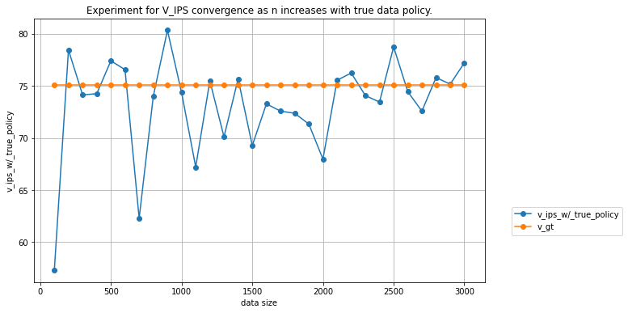

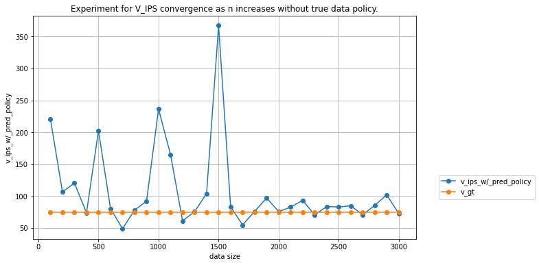

```python
plt.title('Experiment for V_IPS convergence as n increases with true data policy.')
plt.plot(data_n_list, v_ips_trueP_list, '-o', label='v_ips_w/_true_policy')
plt.plot(data_n_list, v_gt_list, '-o', label='v_gt')
plt.legend(bbox_to_anchor=(1.05, 0.3), loc='upper left')
plt.xlabel('data size')
plt.ylabel('v_ips_w/_true_policy')
plt.grid()
plt.show()

plt.title('Experiment for V_IPS convergence as n increases without true data policy.')
plt.plot(data_n_list, v_ips_predP_list, '-o', label='v_ips_w/_pred_policy')
plt.plot(data_n_list, v_gt_list, '-o', label='v_gt')
plt.legend(bbox_to_anchor=(1.05, 0.3), loc='upper left')
plt.xlabel('data size')
plt.ylabel('v_ips_w/_pred_policy')
plt.grid()
plt.show()
```

The following plot shows the convergence of $\hat{V}_{SNIPS}$ as data size ($n$) increases. Plot legends are as follows:

- **v_gt** : $V(\pi^*)$
- **v_snips_w/_true_policy** : $\hat{V}_{SNIPS}(\pi_e; D_{\pi_0}, \pi_0)$
- **v_snips_w/_pred_policy** : $\hat{V}_{SNIPS}(\pi_e; D_{\pi_0}, \hat{\pi}_0)$

Observations are as follows:

1. It is seen that variation in $\hat{V}_{SNIPS}$ reduces as $n$ increases, (i.e. variance reduction with more data).
2. $\hat{V}_{SNIPS}$ is not much sensitive to $\pi_0$ even if it's approximation $\hat{\pi}_0$ is used.
3. $V_{SNIPS}$ is practically highly biased.

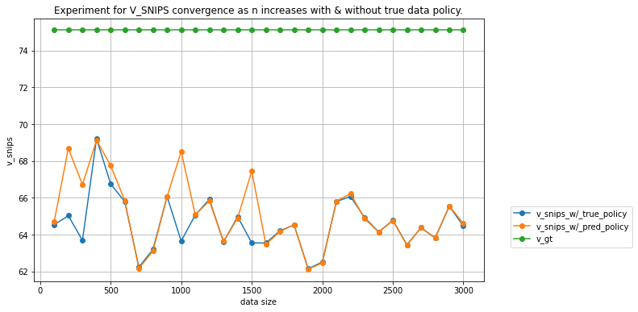

```python
plt.title('Experiment for V_SNIPS convergence as n increases with & without true data policy.')
plt.plot(data_n_list, v_snips_trueP_list, '-o', label='v_snips_w/_true_policy')
plt.plot(data_n_list, v_snips_predP_list, '-o', label='v_snips_w/_pred_policy')
plt.plot(data_n_list, v_gt_list, '-o', label='v_gt')
plt.xlabel('data size')
plt.ylabel('v_snips')
plt.legend(bbox_to_anchor=(1.05, 0.3), loc='upper left')
plt.grid()
plt.show()
```

```python
grid_size = 5
mab = MAB(grid_size)

v_gt = mab.getTruePolicyValue(mab.optimal_policy)
data_n = 500
v_gt_list = []
v_snips_predP_list = []
d_list = []

for i in range(25):
    data_policy = mab.normalizePolicy(np.random.rand(mab.num_state, len(mab.action_space)))
    data = mab.getData(data_policy, data_n)
    v_snips_predP, d = mab.evaluatePolicy(data, mab.optimal_policy, data_policy)
    v_snips_predP_list.append(v_snips_predP)
    v_gt_list.append(v_gt)
    d_list.append(d)
```

Following plot shows the $\hat{V}_{SNIPS}(\pi^*;D_{\pi_i}, \hat{\pi}_i)$ for different $\pi_i$. Observations are as follows:

1. Hypothesis is that the error $|\hat{V}_{SNIPS}-V_{GT}|$ is proportional to deviation between $\pi^*$ and $\pi_i$.
2. Even for different $\pi_i$, bias persist. Next will try to find the true cause of high bias.

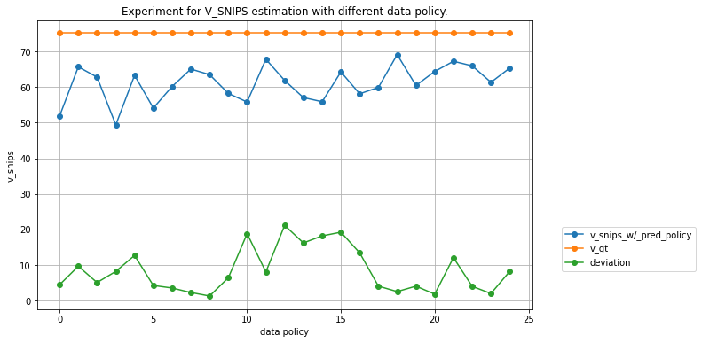

```python
plt.title('Experiment for V_SNIPS estimation with different data policy.')
plt.plot(v_snips_predP_list, '-o', label='v_snips_w/_pred_policy')
plt.plot(v_gt_list, '-o', label='v_gt')
plt.plot(d_list, '-o', label='deviation')
plt.xlabel('data policy')
plt.ylabel('v_snips')
plt.legend(bbox_to_anchor=(1.05, 0.3), loc='upper left')
plt.grid()
plt.show()
```

```python
grid_size = 5
mab = MAB(grid_size)

v_gt = mab.getTruePolicyValue(mab.optimal_policy)
data_n = 500
v_gt_list = []
v_snips_predP_list = []
d_list = []

for i in range(25):
    data_policy = mab.optimal_policy.copy()
    data = mab.getData(data_policy, data_n)
    v_snips_predP, d = mab.evaluatePolicy(data, mab.optimal_policy, data_policy)
    v_snips_predP_list.append(v_snips_predP)
    v_gt_list.append(v_gt)
    d_list.append(d)
```

From previous experiments, it has been concluded that $\hat{V}_{SNIPS}$ is biased and the major cause of the error is the deviation between evaluation policy $\pi^*$ and data policy $\pi_0$. To valiadte the hypothesis, we collected the data from $\pi^*$ and estimated $\hat{V}_{SNIPS}(\pi^*; D_{\pi^*}, \hat{\pi}^*)$. It has been observed the bias reduced significantly.

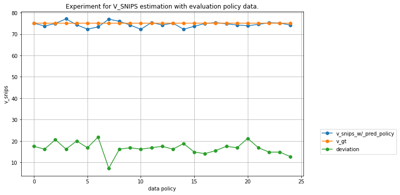

```python
plt.title('Experiment for V_SNIPS estimation with evaluation policy data.')
plt.plot(v_snips_predP_list, '-o', label='v_snips_w/_pred_policy')
plt.plot(v_gt_list, '-o', label='v_gt')
plt.plot(d_list, '-o', label='deviation')
plt.legend(bbox_to_anchor=(1.05, 0.3), loc='upper left')
plt.xlabel('data policy')
plt.ylabel('v_snips')
plt.legend(bbox_to_anchor=(1.05, 0.3), loc='upper left')
plt.grid()
plt.show()
```

```python
def dataResample(data, target_policy):
    data_s, data_a, data_r = data
    source_sar = {}
    next_state = {}
    for s,a,r in zip(data_s, data_a, data_r):
        if (s,a) in source_sar:
            source_sar[(s,a)].append(r)
        else:
            source_sar[(s,a)] = [r]

        s_ = s+a
        if s_ in next_state:
            next_state[s_].add((s,a))
        else:
            next_state[s_] = set()
            next_state[s_].add((s,a))

    target_a = [np.random.choice(mab.action_space, p=target_policy[s]) for s in data_s]
    target_r = []
    remove_index = set()
    for i,(s,a) in enumerate(zip(data_s, target_a)):
        if (s,a) in source_sar and len(source_sar[(s,a)])>4:
            r_mean = np.mean(source_sar[(s,a)])
            r = np.random.normal(loc=r_mean, scale=1.0, size=None)
            target_r.append(r)
        else:
            s_ = s+a
            r_ = []
            if s_ in next_state:
                for (s,a) in next_state[s_]:
                    r_+=source_sar[(s,a)]
                r_mean = np.mean(r_)
                r = np.random.normal(loc=r_mean, scale=2.0, size=None)
                target_r.append(r)
            else:
                remove_index.add(i)

    new_target_s, new_target_a, new_target_r = [],[],[]
    for i,(s,a,r) in enumerate(zip(data_s, target_a, target_r)):
        if i not in remove_index:
            new_target_s.append(s)
            new_target_a.append(a)
            new_target_r.append(r)
    return new_target_s, new_target_a, new_target_r
```

```python
grid_size = 5
mab = MAB(grid_size)

v_gt = mab.getTruePolicyValue(mab.optimal_policy)
data_n = 50
v_gt_list = []
v_snips_predP_list = []
d_list = []

for i in range(25):
    data_policy = mab.normalizePolicy(np.random.rand(mab.num_state, len(mab.action_space)))
    data = mab.getData(data_policy, data_n)
    sampled_data = dataResample(data, mab.optimal_policy)
    v_snips_predP, d = mab.evaluatePolicy(sampled_data, mab.optimal_policy, mab.optimal_policy)
    v_snips_predP_list.append(v_snips_predP)
    v_gt_list.append(v_gt)
    d_list.append(d)
```

## Distribution correction

As it has been discussed that the source of high bias in $\hat{V}_{SNIPS}$ is the deviation of data policy from evaluation policy. In order to fix it, we resample the dataset $D_{\pi_0}$ such that it follows the distribution $pi^*$ i.e. $p(s_i,a_i,r_i) = p(s_i)*\pi^*(a_i|s_i)*p(r_i|s_i,a_i)$. In the resampling step, $r(s, a)$ is estimated using nearest neighbors of $s$ if $(s, a)$ is not present in $D_{\pi_0}$. Results are shown in the following plot.

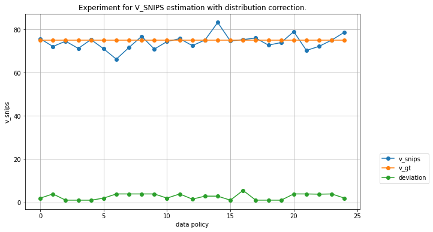

```python
plt.title('Experiment for V_SNIPS estimation with distribution correction.')
plt.plot(v_snips_predP_list, '-o', label='v_snips')
plt.plot(v_gt_list, '-o', label='v_gt')
plt.plot(d_list, '-o', label='deviation')
plt.legend(bbox_to_anchor=(1.05, 0.3), loc='upper left')
plt.xlabel('data policy')
plt.ylabel('v_snips')
plt.legend(bbox_to_anchor=(1.05, 0.3), loc='upper left')
plt.grid()
plt.show()
```

## Conclusion

As stated in a prior study ([Counterfactual Learning and Evaluation for Recommender Systems](https://sites.google.com/cornell.edu/recsys2021tutorial)), *there’s no single winner. One has to understand the pros and cons to make the right choices. SNIPS with distribution correction is enough for easy settings it works well without any hyperparameters but fails in challenging settings.* As there is no interaction of the model with the environment during the learning phase, exploration error will always be in learning methods. Extrapolation error is an error in off-policy evaluation which is introduced by the mismatch between the dataset and true state-action visitation of the evaluation policy. The cause of extrapolation error can be attributed to several related factors:

1. **Absent data** : If (s,$\pi_e(s)$) is unavailable, it is approximated using $D_{\pi0}$ dataset that causes an error.
2. **Model bias** : This is the error introduced in the temporal differencing method. It is not observed in a single-state model but may cause a significant deterioration in MDP.
3. **Behavior policy approximation** : We approximate behavior policy $\pi_0$ using dataset $D_{\pi_0}$ and this leads to high bias.

Detailed exploration error analysis is present in [Off-Policy Deep Reinforcement Learning without Exploration](https://arxiv.org/pdf/1812.02900.pdf) for reference.

## Reference

1. [Off-Policy Deep Reinforcement Learning without Exploration](https://arxiv.org/pdf/1812.02900.pdf)
2. [PLAS: Latent Action Space for Offline Reinforcement Learning](https://offline-rl-neurips.github.io/pdf/17.pdf)
3. [Addressing Extrapolation Error in Deep Offline Reinforcement Learning](https://offline-rl-neurips.github.io/pdf/41.pdf)
4. [ConQUR: Mitigating Delusional Bias in Deep Q-learning](https://www.cs.toronto.edu/~cebly/Papers/CONQUR_ICML_2020_camera_ready.pdf)
5. [Distilled Thompson Sampling: Practical and Efficient Thompson Sampling via Imitation Learning](https://offline-rl-neurips.github.io/pdf/47.pdf)
6. [A Contextual-Bandit Approach to Personalized News Article Recommendation](http://rob.schapire.net/papers/www10.pdf)
7. [Counterfactual risk minimization](https://arxiv.org/pdf/1502.02362.pdf)
8. [Stabilizing Off-Policy Q-Learning via Bootstrapping Error Reduction](https://arxiv.org/pdf/1906.00949.pdf)
9. [Conservative Q-Learning for Offline Reinforcement Learning](https://arxiv.org/pdf/2006.04779.pdf)
10. [COG: Connecting New Skills to Past Experience with Offline Reinforcement Learning](https://arxiv.org/pdf/2010.14500.pdf)
11. [Offline Reinforcement Learning: Tutorial, Review, and Perspectives on Open Problems](https://arxiv.org/pdf/2005.01643.pdf)
12. [A Survey on Offline Reinforcement Learning: Taxonomy, Review, and Open Problems](https://arxiv.org/pdf/2203.01387.pdf)
13. [Counterfactual Learning and Evaluation for Recommender Systems](https://sites.google.com/cornell.edu/recsys2021tutorial)